# M1 CV : TP4

# Histogram Backprojection

Pour cet exercice, votre mission, si vous l'acceptez, sera d'implémenter l'algorithme "Histogram backprojection". Cet algorithme a été proposé par Michael J. Swain , Dana H. Ballard dans leur article "Indexing via color histograms" en 1990.

Cet algorithme est utilisé principalement pour de la segmentation d'image ou pour de la détection d'objets. A partir d'une image et d'une région d'intérêt (Region Of Interest ou ROI), l'histogram backprojection retourne une image de la même taille où chaque pixel correspond à la probabilité que ce pixel appartienne à la région d'intérêt. Cette image est créée grâce à l'analyse des histogrammes 2D de l'image d'entrée et de la ROI, converties en HSV.

La tâche qu'on va réaliser avec histogram backprojection est la segmentation d'images, à savoir la création d'une matrice de même taille que l'image d'entrée, où chaque pixel contient comme valeur la classe de l'objet (exemple en image ci-dessous). Cependant, avec notre algo, on va uniquement segmenter une zone d'intérêt, donc une seule classe d'objet.

[figure not shown]

```python
!pip install opencv-python
```

```python
import cv2
```

```python
# A compléter
# Importer ici les packages qui vous seront nécessaires pour cette partie de l'examen
import cv2
from matplotlib import pyplot as plt
import numpy as np
from skimage.io import imread
import matplotlib.pyplot as plt
```

```python
def get_image(file):
    '''
    Cette fontion permet d'ouvrir des images en couleur
    '''
    #img = cv2.imread(file)#, cv2.IMREAD_GRAYSCALE)
    img = plt.imread(file)
    return img
```

```python
def lever_exception(f):
    '''
    Notre fameuse fonction qui lève des exceptions
    '''
    raise Exception("Il y'a un problème au niveau de la fonction ",f)
```

```python
def print_image(img):
    '''
    Cette fonction sert à afficher des images en couleurs
    '''
    plt.imshow(img)
```

```python
def get_max_pix(img):
    size = get_img_size(img)
    r = []
    g = []
    b = []
    for i in range(size[0]):
        for j in range(size[1]):
            ri, gi, bi = img[i,j]
            r.append(ri)
            g.append(gi)
            b.append(bi)
    return np.array([np.max(r),np.max(g),np.max(b)])
```

```python
def get_img_size(img):
    return img.shape
```

```python
def get_min_pix(img):
    size = get_img_size(img)
    r = []
    g = []
    b = []
    for i in range(size[0]):
        for j in range(size[1]):
            ri, gi, bi = img[i,j]
            r.append(ri)
            g.append(gi)
            b.append(bi)
    return np.array([np.min(r),np.min(g),np.min(b)])
```

```python
def img_normalisation(img):
    size = img.shape
    img_norm = np.zeros((img.shape))#.astype(np.uint8)
    pmin = get_min_pix(img)
    pmax = get_max_pix(img)
    den = pmax - pmin
    for i in range(size[0]):
        for j in range(size[1]):
            img_norm[i,j] = (img[i,j] - pmin)/den
    return img_norm
```

## Partie 1 : Roses are red, Violets are blue...

1) Chargez l'image (rose.png) et la ROI (rose_roi.png) en RGB pour la démonstration et affichez-les.

```python
# A compléter
# Chargement et affichage en RGB de l'image à analyser et de la région d'intérêt
#roi is the object or region of object we need to find
roi = get_image("rose_roi.png")
target = get_image("rose.png")
```

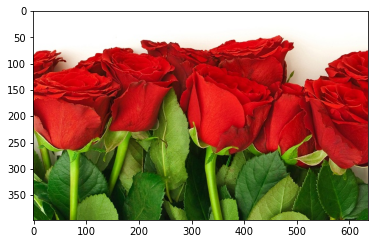

```python
print_image(target)
```

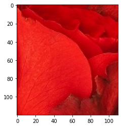

```python
print_image(roi)
```

Vous l'avez compris : l'objectif sera de détecter les têtes de roses rouges. La ROI est une zone extraite de l'image (au centre).

2) Convertissez l'image et la ROI en HSV et affichez les résultats channel par channel (en niveau de gris)

### HSV of ROI

```python
# A compléter
# Conversion HSV et affichage de l'image et de la ROI
hsv = cv2.cvtColor(roi,cv2.COLOR_RGB2HSV)
```

```
Clipping input data to the valid range for imshow with RGB data ([0..1] for floats or [0..255] for integers).
```

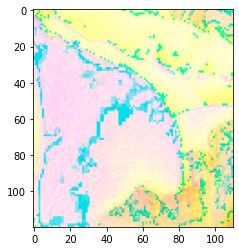

```python
print_image(hsv)
```

```python
h1, s1, v1 = cv2.split(hsv)
```

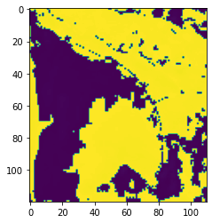

```python
print_image(h1)
```

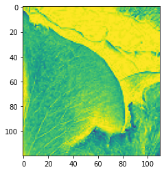

```python
print_image(s1)
```

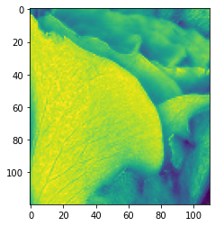

```python
print_image(v1)
```

### HSV of Target

```python
# A compléter
# Conversion HSV et affichage de l'image et de la ROI
hsvt = cv2.cvtColor(target,cv2.COLOR_RGB2HSV)
```

```
Clipping input data to the valid range for imshow with RGB data ([0..1] for floats or [0..255] for integers).
```

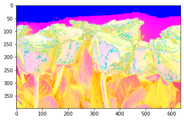

```python
print_image(hsvt)
```

```python
h2, s2, v2 = cv2.split(hsvt)
```

3) Calculez maintenant les histogrammes 2D de l'image HSV et la ROI HSV, qui s'appeleront respectivement I et M. L' histogramme 2D d'une image est une matrice 2D avec en abscisse les valeurs possibles de l'image sur le channel H, et en ordonnée les valeurs possibles de l'image sur le channel S. Par exemple, un histogramme 2D aura aux coordonnées (x,y) le nombre de pixels de l'image correspondante ayant sur le channel H la valeur x ET sur le channel S la valeur y.

Vous pouvez soit coder la fonction à la main, soit utiliser une fonction qui permet de le calculer.

```python
mask = np.zeros(hsvt.shape[:2], np.uint8)
mask[50:300, 0:hsvt.shape[1]] = 255
masked_img = cv2.bitwise_and(hsvt,hsvt,mask = mask)
```

```
Clipping input data to the valid range for imshow with RGB data ([0..1] for floats or [0..255] for integers).
```

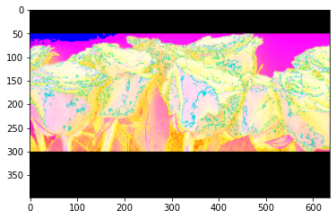

```python
plt.imshow(masked_img)
```

```python
# A compléter
# Calcul des histogrammes 2D de l'image HSV et de la ROI HSV
# h en x et s en y
# M : roi
# I : rose
M = cv2.calcHist([hsv],[0, 1], None, [180, 256], [0, 180, 0, 256] )
I = cv2.calcHist([hsvt],[0, 1], None, [180, 256], [0, 180, 0, 256] )
```

*Checkpoint 1* : Vous pouvez vérifier que votre histogramme est correct grâce aux vérifications suivantes :

### Vérification de la construction des histogrammes 2D avec OpenCV

```python
print(" I[0,0] = ",I[0,0])
print(" I[0,255] = ",I[0,255])
print(" I.sum() = ",I.sum())
print(" M[0,0] = ",M[0,0])
print(" M[0,255] = ",M[0,255])
print(" M.sum() = ",M.sum())
```

```
 I[0,0] =  45052.0
 I[0,255] =  0.0
 I.sum() =  188314.0
 M[0,0] =  2066.0
 M[0,255] =  0.0
 M.sum() =  5324.0
```

4) Calculez la matrice de probabilités R = M/I. Il se peut que vous ayez des valeurs incongrues, mais c'est normal, car I peut valoir 0 parfois. Cela n'influencera pas les résultats futurs, mais remplacez ces valeurs par 0.

```python
R = M/I
```

5) R ici va être utilisée ensuite comme une 'palette'. On va pouvoir construire la matrice B, une image 1 channel de la même taille que notre image à analyser, dont chaque pixel aura comme valeur la probabilité que ce pixel soit de la même classe que la région d'intérêt.

Construisez et affichez maintenant la matrice B, définie grâce à la formule suivante :

\begin{equation*} B(x,y) = min(R[h(x,y),s(x,y)],1) \end{equation*}

avec h et s qui sont respectivement les channels Hue et Saturation de l'image à analyser.

```python
# normalize histogram and apply backprojection
cv2.normalize(M,M,0,255,cv2.NORM_MINMAX)
dst = cv2.calcBackProject([hsvt],[0,1],M,[0,180,0,256],1)
```

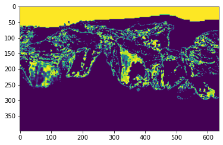

```python
print_image(dst)
```

Si le résultat n'est pas satisfaisant, vous avez la possibilité d'utiliser la fonction OpenCV calcBackProject, où il vous faudra votre image HSV à analyser, et M, l'histogramme de votre ROI en format HSV.

/!\ : Il est fort probable que vous n'ayez pas le même résultat que la version d'OpenCV. Ceci est normal car nous effectuons pas exactement les mêmes opérations que l'algo d'OpenCV. Cependant, l'algorithme d'OpenCV retourne une matrice en uint8, donc il faudra normaliser le résultat pour avoir des valeurs comprises entre 0 et 1.

6) Il est l'heure d'appliquer un filtrage sur B. Pour cela, créer un filtre elliptique de taille 5X5 (utilisé habituellement pour la morphologie mathématique), appliquez ce filtre via convolution sur B, normalisez le résultat en uint8 et affichez le résultat.

```python
# A compléter
# Création du filtre elliptique, application de ce dernier sur B, normalisation et affichage du résultat
```

```python
# Now convolute with circular disc
disc = cv2.getStructuringElement(cv2.MORPH_ELLIPSE,(5,5))
cv2.filter2D(dst,-1,disc,dst)
```

```
array([[4335., 4335., 4335., ..., 4335., 4335., 4335.],
       [4335., 4335., 4335., ..., 4335., 4335., 4335.],
       [4335., 4335., 4335., ..., 4335., 4335., 4335.],
       ...,
       [   0.,    0.,    0., ...,    0.,    0.,    0.],
       [   0.,    0.,    0., ...,    0.,    0.,    0.],
       [   0.,    0.,    0., ...,    0.,    0.,    0.]], dtype=float32)
```

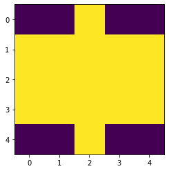

```python
print_image(disc)
```

7) Pour finir, appliquez une binarisation sur cette image pour obtenir un masque indiquant les pixels appartenant à la classe de votre ROI. Le seuil sera défini à la main. Affichez le résultat de cette binarisation.

```python
# A compléter
# Binarisation de B puis affichage du masque de sélection créé
```

```python
# with sklearn
ret,thresh = cv2.threshold(dst,50,255,0)
thresh = cv2.merge((thresh,thresh,thresh))
```

```
Clipping input data to the valid range for imshow with RGB data ([0..1] for floats or [0..255] for integers).
```

[figure not shown]

```python
print_image(thresh)
```

```python
res = cv2.bitwise_and(target,thresh)
```

[figure not shown]

```python
plt.imshow(res)
```

## Partie 2 : Cassiopée, apprentie influenceuse insta

Cassiopée a un seul objectif : percer sur Insta. Cependant, elle n'a pas encore assez de notorieté pour pouvoir avoir de nombreux partenariats et faire des placements de produits. Elle n'a donc pas assez d'argent pour pouvoir réaliser un shooting photo sur les plages de Dubaï et est donc coincée dans le Poitou-Charentes.

A partir de ce que vous avez implémenté précédemment, appliquez l'histogram backprojection sur la dernière photo de Cassiopée, allongée dans l'herbe (Cassiopee.jpg), et envoyez la à Dubaï avec un subtil montage photo grâce au fond disponible ("Dubai.jpg").

*Indice :* Cassiopée est difficile à segmenter... Il faudrait peut-être segmenter tout sauf Cassiopée...

```python
# A compléter
# A vous de jouer...
```

```python
cassiopee = get_image("Cassiopee.jpg")
```

```python
dubai = get_image("Dubai.jpg")
```

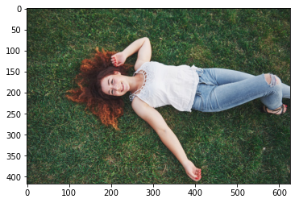

```python
print_image(cassiopee)
```

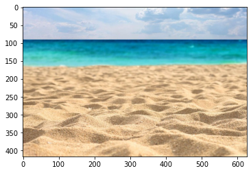

```python
print_image(dubai)
```

```python
lower = np.array([0,0,110])
upper = np.array([255,255,255])
```

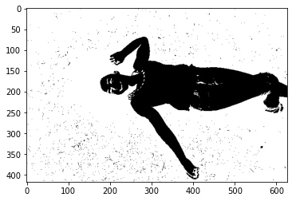

```python
mask = cv2.inRange(image_copy, lower,upper)
plt.imshow(1-(mask/255), cmap='gray')
```

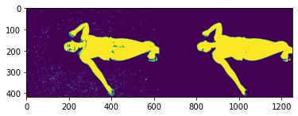

```python
median = cv2.medianBlur(mask, 7)
compare = np.concatenate((mask, median), axis=1) #side by side comparison
print_image(compare)
```

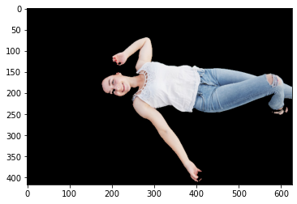

```python
masked_image = np.copy(image_copy)
masked_image[median == 0] = [0, 0, 0]
plt.imshow(masked_image)
```

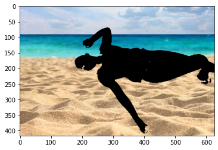

```python
background_image = np.copy(dubai)
crop_background = np.copy(background_image)

crop_background[median != 0] = [0,0,0]
plt.imshow(crop_background)
```

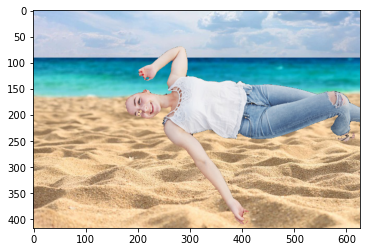

```python
complete_image = masked_image + crop_background
plt.imshow(complete_image)
```